# PNW Wine Analysis

## Bar Graph

I just decided to add a visualisation because I thought it would be cool. (Unnecessary but I had fun.)

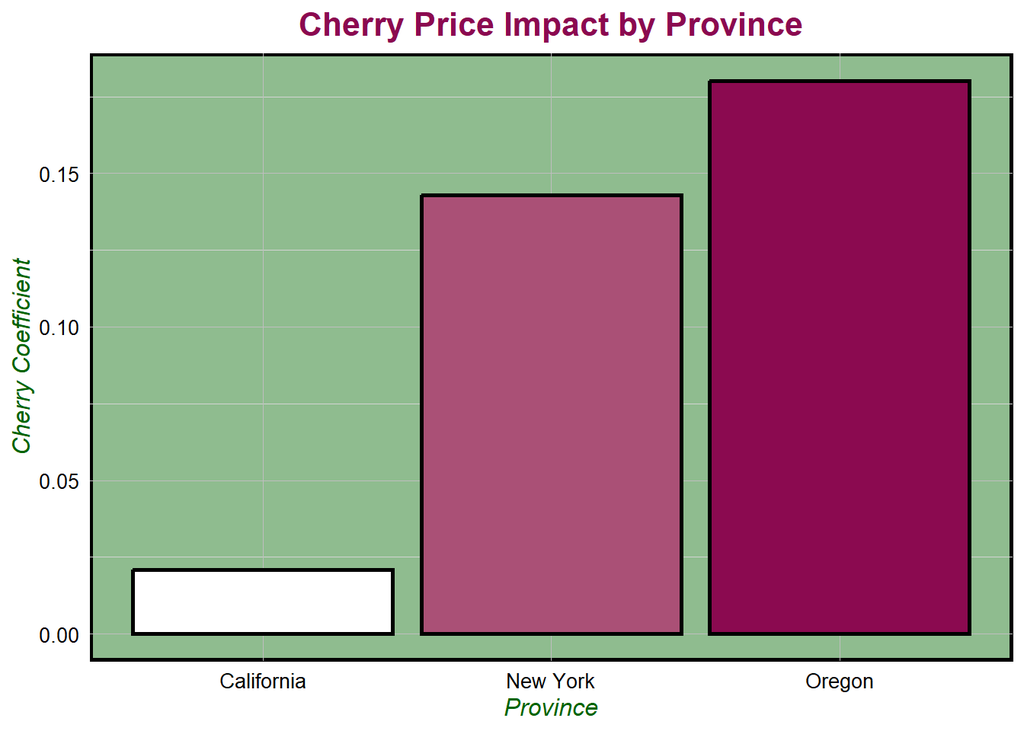

```r
library(ggplot2)

ggplot(impact_df,
       aes(x = reorder(Province, Cherry_Coefficient),
           y = Cherry_Coefficient, fill = Cherry_Coefficient)) +
  geom_bar(stat = "identity",
           color = "black",
           size = 1) +
  labs(title = "Cherry Price Impact by Province",
       x = "Province",
       y = "Cherry Coefficient") +
  theme_minimal() +
  theme(
    plot.title = element_text(family = "Comic Sans MS",
                                       size = 16,
                                       face = "bold",
                                       color = "deeppink4",
                                       hjust = 0.5),
    axis.title = element_text(family = "Arial",
                              size = 12,
                              face = "italic",
                              color = "darkgreen"),
    axis.text = element_text(family = "Arial",
                             size = 10,
                             color = "black"),
    panel.grid.major = element_line(color = "gray",
                                    size = 0.2),
    panel.grid.minor = element_line(color = "lightgray",
                                    size = 0.1),
    panel.background = element_rect(fill = "darkseagreen",
                                    color = "black",
                                    size = 1.5),
    legend.position = "none"
  ) +
  scale_fill_gradient(low = "white",
                      high = "deeppink4")
```

## Model Accuracy Check

This section checks the proportion of wines from New York in the dataset, helping to assess the generalizability of the model across regions.

```r
# Directly calculate the proportion of "New York" in the province column
mean(wine$province == "New York")
```

```
## [1] 0.08892567
```

Output: [1] 0.08892567 The output value 0.08 means that approximately 8.89% of the wines in the dataset come from New York. Importance? This proportion can help assess whether r the dataset has a balanced representation of wines from different regions. In this case, only about 8.89% of the wines are from New York, which may indicate a relatively small representation of this state in the dataset. This could influence how well the model generalizes to New York wines, especially if other states are overrepresented.

## On Ethics

Vignettes, are crucial because they help: 1. Highlight biases and fairness issues 2. Test ethical bounderies 3. Encourage everyone to uphold empathy and human impact 4. Strengthen accountability 5. Identify unintended consequences 6. Communicate to different branches of professions

## My stance on: Ignorance is no Excuse

My approach to this would begin with understanding the specific focus and objectives of the project. In some cases, removing variables like age, income, or gender might not be unethical, particularly if the goal is to protect civilian anonymity and reduce bias. However, in a context like predicting job loss due to changing federal policies, these variables could be directly relevant to the model. They can significantly influence how individuals are impacted by policy shifts. While dropping these features might help reduce potential bias and protect personal privacy, it could also make the model less accurate or less predictive. To find the right balance between ethical considerations and model performance, I would take the following steps: Preserve the Original Data: First, I would duplicate the data to ensure the original dataset remains intact. Experiment: Next, I would run the model both with and without these variables to see how their removal affects the results. Comparison: Finally, I would compare the model outcomes to determine whether the removal of these features significantly impacts the predictive power and fairness of the model. This approach would allow me to ensure that the model remains both ethically sound and effective in terms of its predictions, while also understanding the trade-offs involved in dropping these variables. Dropping these variables does not necessarily solve the ethical issue; it simply addresses one aspect of potential ethical concerns, like bias or fairness. While removing these variables can reduce the risk of discriminatory outcomes (especially if the model makes biased decisions based on these factors), it doesn’t guarantee that the model is ethical or fair in its entirety.